# 反向传播

2026-11-20

课程代码均在如下 GitHub 仓库开源：https://github.com/GHe0000/xmu_machine_learning

项目自动生成网页地址：https://ghe0000.github.io/xmu_machine_learning

## 目录

- 作业要求
- 背景补充
  - 使用求和约定推导反向传播
- 数据集生成和划分
  - 计算前准备
  - 数据集生成
- 层的实现
- 训练
- 最优模型评估
- 不同阶段的拟合曲线和特征空间函数曲线
- 为何从 x=0 开始拟合
- 自动微分
- 结论
- 参考资料以及 AI 使用说明
  - 参考资料
  - AI 使用说明
- 致谢
- 附一：问题
  - 为什么较大学习率下，$H$ 越大反而越容易梯度不稳定
  - 宽网络更快逃离“平台期”是否源于随机初始化概率
  - 继续增大 Epoch 后，模型是否一定会进入过拟合
  - 成功拟合是否有 $H$ 的下界
  - 不同激活函数现象是否类似
  - 不同优化器的效果
- 附二：学习心得

## 作业要求

利用 $\sin (24x)$ 加随机数的方式生成数据集，参照本课程PPT，手动编程实现单隐含层多层感知机的反向传播训练（建议训练样本 60 个左右；验证集样本 20 个左右）

要求：

- 1）画出学习曲线，即训练集和验证集的 loss 函数随迭代次数的变化
- 2）根据学习曲线的不同阶段，画出模型输出函数，有什么规律？
- 3）根据学习曲线的不同阶段，画出特征函数（即隐含层输出函数），有什么规律？

## 背景补充

### 使用求和约定推导反向传播

这里我们使用理论力学中常常使用的 Einstein 求和约定简化推导（信息学可能更喜欢用矩阵表示，矩阵表示容易优化算法进行加速，但使用求和约定推导比较容易，在使用求和约定的情况下，不需要知道任何矩阵求导的法则，只需要当成普通函数求导+指标法则即可，最后也可以转成矩阵形式，同时也方便推广）.

考虑一个包含输入层、隐藏层和输出层的三层神经网络. 设训练样本数为 $m$，输入维度为 $d$，隐藏层神经元数为 $H$，输出维度为 $r$.

定义增广输入

$$ \widetilde a^{(1)}_{si} = \begin{cases} x_{si},&1\le i\le d\\ 1,&i=d+1 \end{cases} $$

权重矩阵为

$$ W^{(1)}\in\mathbb R^{(d+1)\times H}, \quad W^{(2)}\in\mathbb R^{(H+1)\times r} $$

其中权重矩阵的最后一行对应偏置的系数. 第一层的输出为：

$$ z^{(2)}_{sh} = a^{(1)}_{si}W^{(1)}_{ih} ,\quad a^{(2)}_{sh}=\sigma(z^{(2)}_{sh}) $$

这里我们使用 sigmoid 激活函数.

$$ \sigma(z)=\frac{1}{1+e^{-z}} $$

对隐藏层输出进行增广，记

$$ \widetilde a^{(2)}_{sh}= \begin{cases} a^{(2)}_{sh},&1\le h\le H\\ 1,&h=H+1 \end{cases} $$

下面我们考虑反向传播. 考虑第 $l$ 层全连接层与 Sigmoid 激活函数. 前向传播为

$$ z^{(l)}_{sj}=\widetilde a^{(l-1)}_{si}W^{(l)}_{ij}, \quad a^{(l)}_{sj}=\sigma(z^{(l)}_{sj}) $$

已知上游传入的梯度

$$ G^{(l)}_{sj}=\frac{\partial L}{\partial z^{(l)}_{sj}} $$

由链式法则，权重梯度为

$$ \frac{\partial L}{\partial W^{(l)}_{ij}} = \widetilde a^{(l-1)}_{si}G^{(l)}_{sj} $$

向前一层传播的梯度为

$$ \frac{\partial L}{\partial a^{(l-1)}_{si}} = G^{(l)}_{sj}W^{(l)}_{ij} $$

这里 $i$ 仅包含实际神经元，不包含偏置.

指标形式写成矩阵形式，得到：

$$ \begin{aligned} \nabla_{W^{(l)}}L &=(\widetilde A^{(l-1)})^{\mathsf T}G^{(l)}\\ \nabla_{A^{(l-1)}}L &=G^{(l)}(W^{(l)}_{:-1,:})^{\mathsf T} \end{aligned} $$

此即全连接层的反向传播公式.

对于 Sigmoid 激活函数，其导数为

$$ a_{si}=\sigma(z_{si}),\quad \sigma'(z_{si})=a_{si}(1-a_{si}) $$

由链式发展，已知上游梯度 $\partial L/\partial a_{si}$，得到

$$ \frac{\partial L}{\partial z_{si}} = \frac{\partial L}{\partial a_{si}} a_{si}(1-a_{si}) $$

通过反向传播得到每一层的梯度后，使用梯度下降优化，梯度下降更新为

$$ W^{(l)}\leftarrow W^{(l)}-\alpha\nabla_{W^{(l)}}L $$

这样每一层的 `backward` 只需要接收当前层的 $G^{(l)}$，计算并保存权重梯度，再返回 $G^{(l-1)}$. 从而可以抽象成 `class` 从而方便进行推广.

## 数据集生成和划分

### 计算前准备

```python
import numpy as np
import numba as nb
from numba.experimental import jitclass
import pandas as pd
import scipy
import matplotlib as mpl
import matplotlib.pyplot as plt
import matplotlib.animation as animation
import ipywidgets as ipw

from matplotlib.backends.backend_agg import FigureCanvasAgg
from IPython.display import display, HTML

import time

%matplotlib widget


# 将静态图像直接嵌入 Jupyter Notebook
def display_inline(fig):
    try:
        try:
            fig.canvas.draw()
            fig.canvas.flush_events()
        except Exception:
            pass
        fig.set_canvas(FigureCanvasAgg(fig))
        try:
            import matplotlib.text as mtext
            if hasattr(mtext, "_get_text_metrics_with_cache_impl"):
                mtext._get_text_metrics_with_cache_impl.cache_clear()
        except Exception:
            pass
        try:
            fig.draw_without_rendering()
        except Exception:
            pass
        fig.tight_layout()
        fig.canvas.draw()
        display(fig)

    finally:
        plt.close(fig)

plt.rcParams.update({
    "font.family": ["SimSun", "Times New Roman"],
    "font.size": 14,
    "mathtext.fontset": "cm",
    "axes.unicode_minus": False,
    "axes.titlesize": 14,
    "axes.labelsize": 14,
    "xtick.labelsize": 14,
    "ytick.labelsize": 14,
    "legend.fontsize": 14,
    "figure.titlesize": 14,
})
```

### 数据集生成

使用目标函数

$$ f(x)=\sin(24x) $$

在区间 $[0,1]$ 内随机生成 100 个输入样本，并加入高斯噪声

$$ \epsilon_i\sim\mathcal N(0,\sigma^2) $$

取 $\sigma = 0.05$. 我们将数据随机划分为 60 个训练样本、20 个验证样本、20 个测试样本.

```python
rng = np.random.default_rng(42)

n_train = 60
n_val = 20
n_test = 20
n_total = n_train + n_val + n_test

noise_std = 0.05

x = rng.uniform(0.0, 1.0, size=(n_total, 1))
y_true = np.sin(24.0 * x)

y = y_true + rng.normal(0.0, noise_std, size=y_true.shape)
```

```python
idx = rng.permutation(n_total)
idx_train = idx[:n_train]
idx_val = idx[n_train:n_train + n_val]
idx_test = idx[n_train + n_val:]

x_train, y_train = x[idx_train], y[idx_train]
x_val, y_val = x[idx_val], y[idx_val]
x_test, y_test = x[idx_test], y[idx_test]
```

绘制采样点观察分布

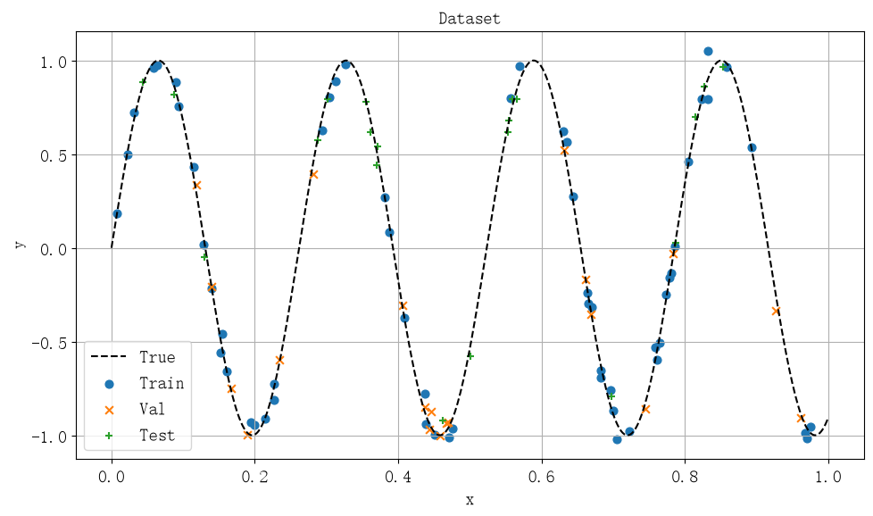

```python
x_grid = np.linspace(0.0, 1.0, 500).reshape(-1, 1)
X_grid = 2.0 * x_grid - 1.0
y_grid = np.sin(24.0 * x_grid)

fig, ax = plt.subplots(figsize=(10, 6))

ax.plot(x_grid, y_grid, "k--", label="True")
ax.scatter(x_train, y_train, s=40, label="Train")
ax.scatter(x_val, y_val, s=40, marker="x", label="Val")
ax.scatter(x_test, y_test, s=40, marker="+", label="Test")
ax.set(xlabel="x", ylabel="y", title="Dataset")
ax.grid(True)
ax.legend()
display_inline(fig)
```

## 层的实现

我们将全连接和激活函数分别定义为独立的类，每一层均包含三个主要方法.

- `forward` 计算该层的输出，并保存反向传播所需的数据.
- `backward` 接收后续层传来的梯度，根据链式法则计算本层梯度，并返回传递给前一层的梯度.
- `update` 更新本层的可训练参数，对于没有参数的激活层不执行操作.

对于全连接层 `Dense`，将偏置放入权重矩阵，前向传播为

$$ Z=\widetilde A_{\mathrm{in}}W $$

设接收到的梯度为

$$ G=\frac{\partial L}{\partial Z} $$

权重梯度为

$$ \Delta W=\widetilde A_{\mathrm{in}}^{\mathsf T}G $$

向前一层传递的梯度为

$$ \frac{\partial L}{\partial A_{\mathrm{in}}} =GW_{\mathrm{no\ bias}}^{\mathsf T} $$

`update` 执行梯度下降

$$ W\leftarrow W-\frac{\alpha}{m}\Delta W $$

对于激活层 `Sigmoid`，前向传播为

$$ A=\sigma(Z)=\frac{1}{1+e^{-Z}} $$

反向传播计算

$$ \frac{\partial L}{\partial Z}=\frac{\partial L}{\partial A}\odot A\odot(1-A) $$

```python
@jitclass([
    ("W", nb.float64[:, ::1]),
    ("dW", nb.float64[:, ::1]),
    ("cache", nb.float64[:, ::1])
])
class Dense:
    def __init__(self, n_in, n_out, rng):
        self.W = rng.normal(0,1,size=(n_in + 1, n_out))
        self.W[-1] = 0 # 惯例，偏置不随机初始化
        self.dW = np.zeros_like(self.W)
        self.cache = np.empty((0, 0)) # 缓存前项传播计算，从而避免反向传播再次计算

    def forward(self, x):
        a = np.empty((x.shape[0], x.shape[1] + 1))
        a[:, :-1] = x
        a[:, -1] = 1.0
        self.cache = a
        return a @ self.W

    def backward(self, grad, ctx=None):
        a = self.cache if ctx is None else ctx
        self.dW += a.T @ grad
        return (grad @ self.W.T)[:, :-1]

    def update(self, lr, m):
        self.W -= lr / m * self.dW
        self.dW.fill(0)

@jitclass([
    ("cache", nb.float64[:, ::1])
])
class Sigmoid:
    def __init__(self):
        self.cache = np.empty((0, 0))

    def forward(self, x):
        a = 1.0 / (1.0 + np.exp(-x))
        self.cache = a
        return a

    def backward(self, grad, ctx=None):
        a = self.cache if ctx is None else ctx
        return grad * a * (1.0 - a)

    def update(self, lr, m):
        pass
```

损失函数使用 MSE，同样抽象成层的形式，提供正向传播和反向传播.

正向传播公式 $$ L=\frac{1}{2} (a_{so}-y_{so}) (a_{so}-y_{so}) $$

反向传播公式 $$ \frac{\partial L}{\partial a_{so}}=(a_{so}-y_{so}) $$

```python
@jitclass([
    ("target", nb.float64[:, ::1]),
    ("cache", nb.float64[:, ::1])
])
class MSELoss:
    def __init__(self, target):
        self.target = target
        self.cache = np.empty((0, 0))

    def forward(self, pred):
        residual = pred - self.target
        self.cache = residual
        return 0.5 * np.sum(residual ** 2)

    def backward(self, grad=1.0, ctx=None):
        residual = self.cache if ctx is None else ctx
        return grad * residual

    def update(self, lr, m):
        pass
```

## 训练

这里我们使用 1-H-1 的神经网络模型，激活函数取 Sigmoid，H 先取 5 学习率 $\eta=0.5$，先训练 $10^4$ 轮 Epoch 观察网络的 Loss.

```python
@nb.njit
def train(dense1, sigmoid, dense2, loss_train, loss_val, x_train, x_val, epochs, lr):
    train_history = np.empty(epochs)
    val_history = np.empty(epochs)
    m = len(x_train)

    for epoch in range(epochs):
        # 前向传播
        z1 = dense1.forward(x_train)
        a1 = sigmoid.forward(z1)
        pred = dense2.forward(a1)
        loss_train.forward(pred)

        # 反向传播
        grad = loss_train.backward()
        grad = dense2.backward(grad)
        grad = sigmoid.backward(grad)
        dense1.backward(grad)

        # 更新参数
        dense1.update(lr, m)
        dense2.update(lr, m)

        # 记录损失
        train_pred = dense2.forward(sigmoid.forward(dense1.forward(x_train)))
        val_pred = dense2.forward(sigmoid.forward(dense1.forward(x_val)))
        train_history[epoch] = loss_train.forward(train_pred) / m
        val_history[epoch] = loss_val.forward(val_pred) / len(x_val)
    return train_history, val_history
```

```python
H = 5
epochs = 10000
lr = 0.5

rng = np.random.default_rng(3407)

dense1 = Dense(1, H, rng)
sigmoid = Sigmoid()
dense2 = Dense(H, 1, rng)

loss_train = MSELoss(y_train)
loss_val = MSELoss(y_val)

train_history, val_history = train(
    dense1, sigmoid, dense2,
    loss_train, loss_val,
    x_train, x_val, epochs, lr
)
```

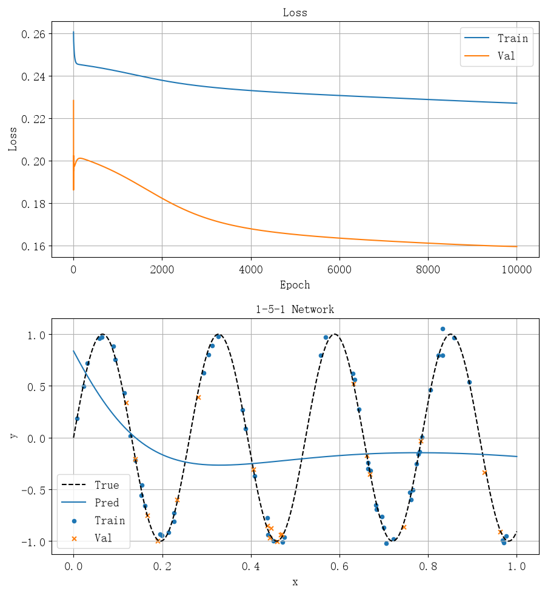

```python
x_grid = np.linspace(0, 1, 500).reshape(-1, 1)
y_grid = np.sin(24 * x_grid)
pred_grid = dense2.forward(sigmoid.forward(dense1.forward(x_grid)))

epochs_history = np.arange(1,epochs + 1)

fig, axes = plt.subplots(2, 1, figsize=(10, 10))
axes[0].plot(epochs_history, train_history, label="Train")
axes[0].plot(epochs_history, val_history, label="Val")
axes[0].set(xlabel="Epoch", ylabel="Loss", title="Loss")
axes[0].grid(True)
axes[0].legend()

axes[1].plot(x_grid, y_grid, "k--", label="True")
axes[1].plot(x_grid, pred_grid, label="Pred")
axes[1].scatter(x_train, y_train, s=20, label="Train")
axes[1].scatter(x_val, y_val, s=25, marker="x", label="Val")
axes[1].set(xlabel="x", ylabel="y", title=f"1-{H}-1 Network")
axes[1].grid(True)
axes[1].legend()

display_inline(fig)
```

可见，这里的拟合曲线并没有很好拟合我们的数据. 可能是训练 Epoch 不够导致的. 我们增大 Epoch 观察.

```python
H = 5
epochs = 200000
lr = 0.5

rng = np.random.default_rng(3407)

dense1 = Dense(1, H, rng)
sigmoid = Sigmoid()
dense2 = Dense(H, 1, rng)

loss_train = MSELoss(y_train)
loss_val = MSELoss(y_val)

train_history, val_history = train(
    dense1, sigmoid, dense2,
    loss_train, loss_val,
    x_train, x_val, epochs, lr
)
```

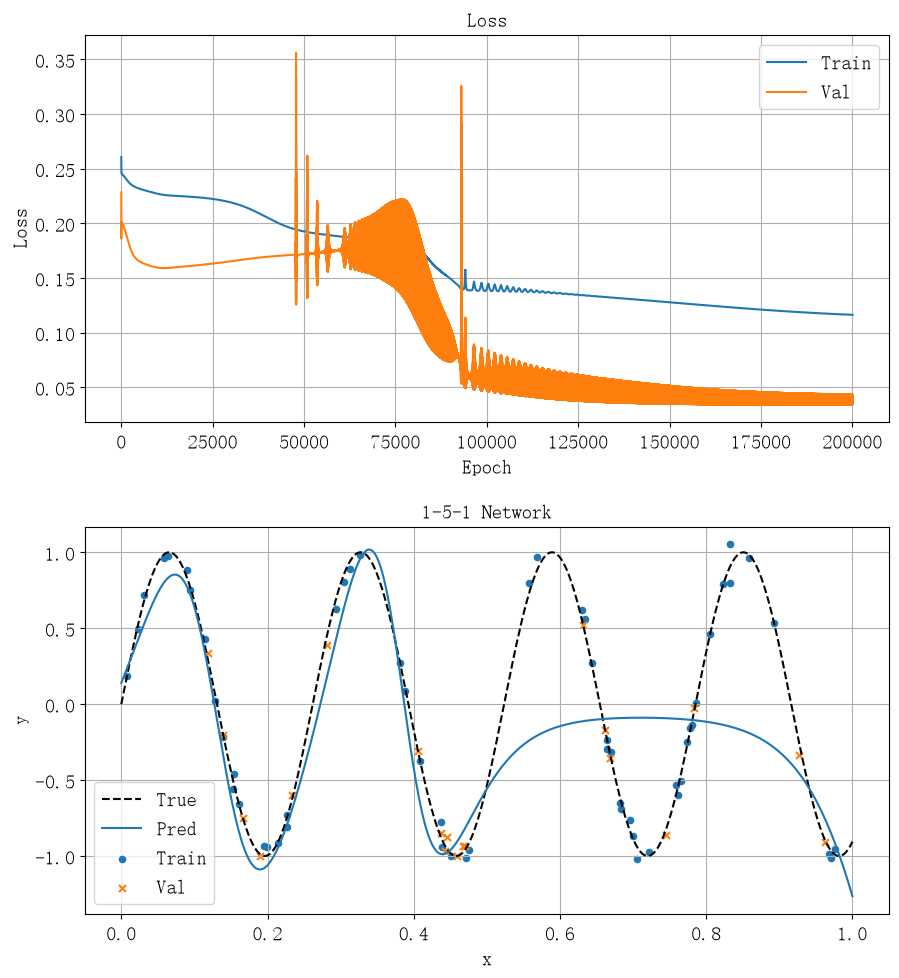

```python
x_grid = np.linspace(0, 1, 500).reshape(-1, 1)
y_grid = np.sin(24 * x_grid)
pred_grid = dense2.forward(sigmoid.forward(dense1.forward(x_grid)))

epochs_history = np.arange(1,epochs + 1)

fig, axes = plt.subplots(2, 1, figsize=(10, 10))
axes[0].plot(epochs_history, train_history, label="Train")
axes[0].plot(epochs_history, val_history, label="Val")
axes[0].set(xlabel="Epoch", ylabel="Loss", title="Loss")
axes[0].grid(True)
axes[0].legend()

axes[1].plot(x_grid, y_grid, "k--", label="True")
axes[1].plot(x_grid, pred_grid, label="Pred")
axes[1].scatter(x_train, y_train, s=20, label="Train")
axes[1].scatter(x_val, y_val, s=25, marker="x", label="Val")
axes[1].set(xlabel="x", ylabel="y", title=f"1-{H}-1 Network")
axes[1].grid(True)
axes[1].legend()

display_inline(fig)
```

可以看见，随着我们的训练轮数增大，预测曲线开始能吻合数据的高频结构. 我们进一步增大 Epoch 观察.

```python
H = 5
epochs = 1000000
lr = 0.5

rng = np.random.default_rng(3407)

dense1 = Dense(1, H, rng)
sigmoid = Sigmoid()
dense2 = Dense(H, 1, rng)

loss_train = MSELoss(y_train)
loss_val = MSELoss(y_val)

train_history, val_history = train(
    dense1, sigmoid, dense2,
    loss_train, loss_val,
    x_train, x_val, epochs, lr
)
```

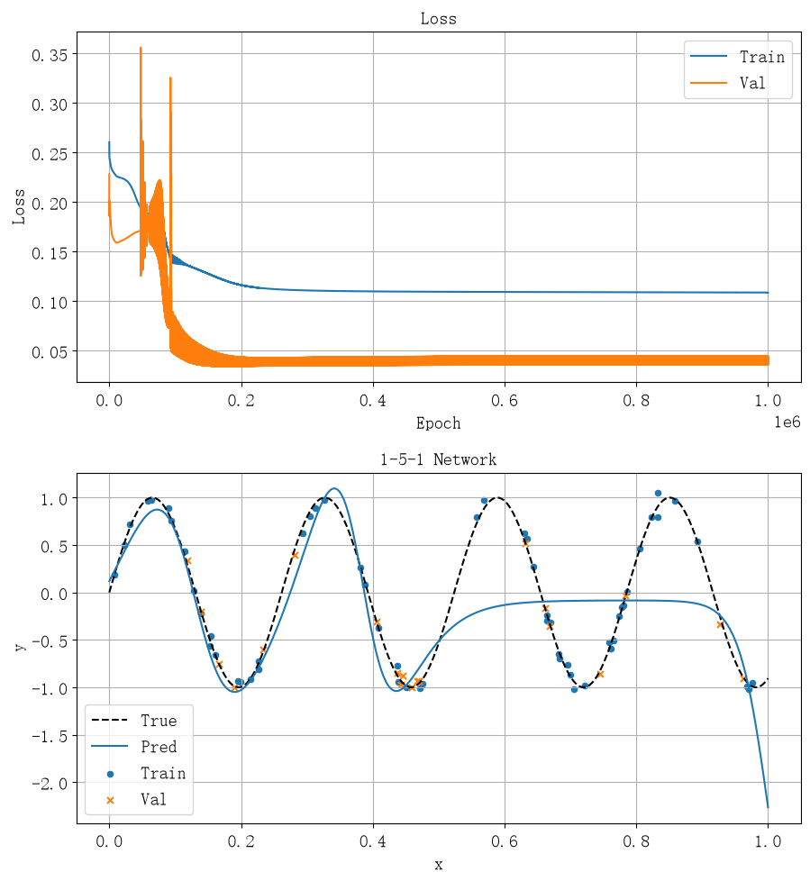

```python
x_grid = np.linspace(0, 1, 500).reshape(-1, 1)
y_grid = np.sin(24 * x_grid)
pred_grid = dense2.forward(sigmoid.forward(dense1.forward(x_grid)))

epochs_history = np.arange(1,epochs + 1)

fig, axes = plt.subplots(2, 1, figsize=(10, 10))
axes[0].plot(epochs_history, train_history, label="Train")
axes[0].plot(epochs_history, val_history, label="Val")
axes[0].set(xlabel="Epoch", ylabel="Loss", title="Loss")
axes[0].grid(True)
axes[0].legend()

axes[1].plot(x_grid, y_grid, "k--", label="True")
axes[1].plot(x_grid, pred_grid, label="Pred")
axes[1].scatter(x_train, y_train, s=20, label="Train")
axes[1].scatter(x_val, y_val, s=25, marker="x", label="Val")
axes[1].set(xlabel="x", ylabel="y", title=f"1-{H}-1 Network")
axes[1].grid(True)
axes[1].legend()

display_inline(fig)
```

可见，长 Epoch 后拟合曲线并没有更好. 这里我们猜测是因为学习率较大，导致最后模型不能收敛. 因此我们减小学习率计算.

```python
H = 5
epochs = 5000000
lr = 0.1

rng = np.random.default_rng(3407)

dense1 = Dense(1, H, rng)
sigmoid = Sigmoid()
dense2 = Dense(H, 1, rng)

loss_train = MSELoss(y_train)
loss_val = MSELoss(y_val)

train_history, val_history = train(
    dense1, sigmoid, dense2,
    loss_train, loss_val,
    x_train, x_val, epochs, lr
)
```

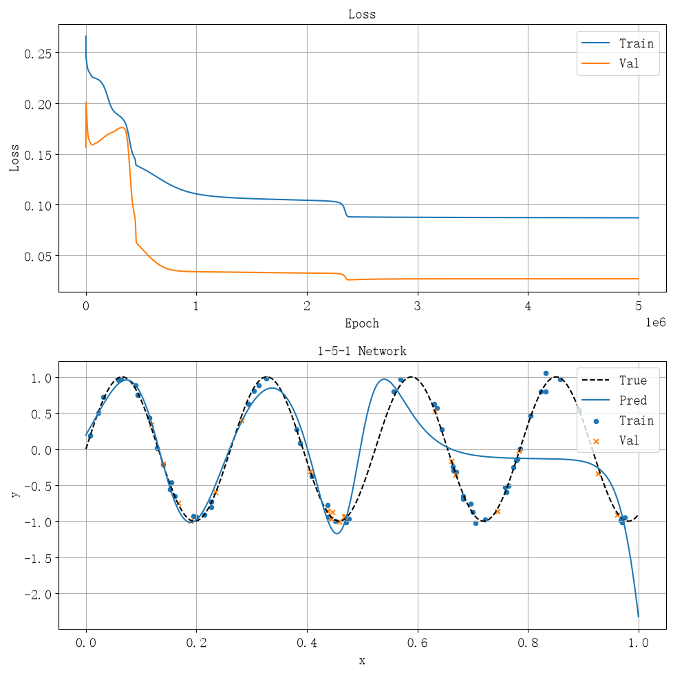

```python
x_grid = np.linspace(0, 1, 500).reshape(-1, 1)
y_grid = np.sin(24 * x_grid)
pred_grid = dense2.forward(sigmoid.forward(dense1.forward(x_grid)))

epochs_history = np.arange(1,epochs + 1)

fig, axes = plt.subplots(2, 1, figsize=(10, 10))
axes[0].plot(epochs_history, train_history, label="Train")
axes[0].plot(epochs_history, val_history, label="Val")
axes[0].set(xlabel="Epoch", ylabel="Loss", title="Loss")
axes[0].grid(True)
axes[0].legend(loc="upper right")

axes[1].plot(x_grid, y_grid, "k--", label="True")
axes[1].plot(x_grid, pred_grid, label="Pred")
axes[1].scatter(x_train, y_train, s=20, label="Train")
axes[1].scatter(x_val, y_val, s=25, marker="x", label="Val")
axes[1].set(xlabel="x", ylabel="y", title=f"1-{H}-1 Network")
axes[1].grid(True)
axes[1].legend(loc="upper right")

display_inline(fig)
```

拟合效果稍微变好一点. 这里学习率若设置更小，且 Epoch 更大，拟合效果应该会更好. 但计算成本也会很大（小矩阵+长计算轮数很难并行化加速，基本只能吃满一个核心）

这里我们换一个思路，改变 $H$ 观察隐藏层大小是否能加速收敛.

我们取 $H={5,15,25,35,45}$ 并绘制五条曲线的 Train/Val Loss.

使用 CPU 并行扫描，取学习率 $\eta=0.5$，训练轮数 $2\times10^5$

```python
@nb.njit(parallel=True)
def scan_H(Hs, rngs, x_train, x_val, y_train, y_val, epochs, lr):
    train_histories = np.empty((len(Hs), epochs))
    val_histories = np.empty((len(Hs), epochs))
    max_H = np.max(Hs)
    W1s = np.zeros((len(Hs), 2, max_H))
    W2s = np.zeros((len(Hs), max_H + 1, 1))

    for i in nb.prange(len(Hs)):
        H = Hs[i]
        rng = rngs[i]

        dense1 = Dense(1, H, rng)
        sigmoid = Sigmoid()
        dense2 = Dense(H, 1, rng)

        loss_train = MSELoss(y_train)
        loss_val = MSELoss(y_val)

        train_history, val_history = train(
            dense1, sigmoid, dense2,
            loss_train, loss_val,
            x_train, x_val, epochs, lr
        )
        train_histories[i] = train_history
        val_histories[i] = val_history
        W1s[i, :, :H] = dense1.W
        W2s[i, :H + 1, :] = dense2.W
    return train_histories, val_histories, W1s, W2s


Hs = np.array([5, 15, 25, 35, 45])
rngs = tuple(np.random.default_rng(3407) for _ in Hs)
epochs = 200000
lr = 0.5

train_histories, val_histories, W1s, W2s = scan_H(
    Hs, rngs, x_train, x_val, y_train, y_val, epochs, lr
)
```

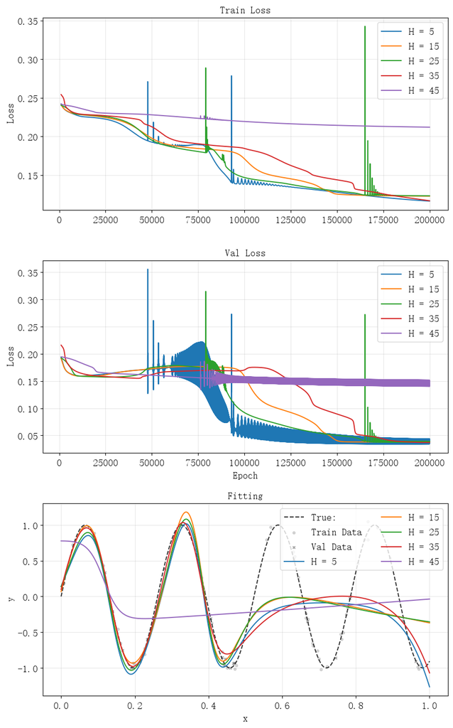

```python
def predict(x, W1, W2):
    x_aug = np.hstack([x, np.ones((len(x), 1))])
    h = 1.0 / (1.0 + np.exp(-(x_aug @ W1)))
    h_aug = np.hstack([h, np.ones((len(h), 1))])
    return h_aug @ W2

fig, axes = plt.subplots(3, 1, figsize=(10, 15))
axes[0].sharex(axes[1])

start_epoch = 1000
step = max(1, (epochs - start_epoch) // 5000)
epoch_axis = np.arange(start_epoch + 1, epochs + 1, step)

axes[2].plot(x_grid, y_grid, "k--", lw=1.5, alpha=0.8, label="True:")
axes[2].scatter(x_train, y_train, s=12, alpha=0.3, color="gray", label="Train Data")
axes[2].scatter(x_val, y_val, s=12, alpha=0.35, color="black", marker="x", label="Val Data")

for i, H in enumerate(Hs):
    color = f"C{i}"
    axes[0].plot(
        epoch_axis,
        train_histories[i, start_epoch::step],
        color=color,
        label=f"H = {H}"
    )
    axes[1].plot(
        epoch_axis,
        val_histories[i, start_epoch::step],
        color=color,
        label=f"H = {H}"
    )
    y_pred = predict(x_grid, W1s[i, :, :H], W2s[i, :H + 1, :])
    axes[2].plot(x_grid, y_pred, color=color, label=f"H = {H}")

for ax, title in zip(axes[:2], ["Train Loss", "Val Loss"]):
    ax.set(title=title, ylabel="Loss")
    ax.legend()
    ax.grid(True, alpha=0.3)

axes[1].set_xlabel("Epoch")
axes[2].set(title="Fitting", xlabel="x", ylabel="y")
axes[2].legend(ncol=2)
axes[2].grid(True, alpha=0.3)
display_inline(fig)
```

可以看见，$H$ 增大后，模型反而更难收敛，且 Train Loss 更容易突然出现一个峰. 呈现很明显的梯度不稳定的情况. 而且从拟合情况来看，不同网络拟合情况不同，$H$ 较小的拟合情况反而更好一些. 这后续可能需要解释. 可能是因为，$H$ 较小时，当前学习率下梯度下降比较稳定.

这里我们猜测是学习率过大导致的，我们减小学习率重新尝试.

```python
Hs = np.array([5, 15, 25, 35, 45])
rngs = tuple(np.random.default_rng(3407) for _ in Hs)
epochs = 200000
lr = 0.05

train_histories, val_histories, W1s, W2s = scan_H(
    Hs, rngs, x_train, x_val, y_train, y_val, epochs, lr
)
```

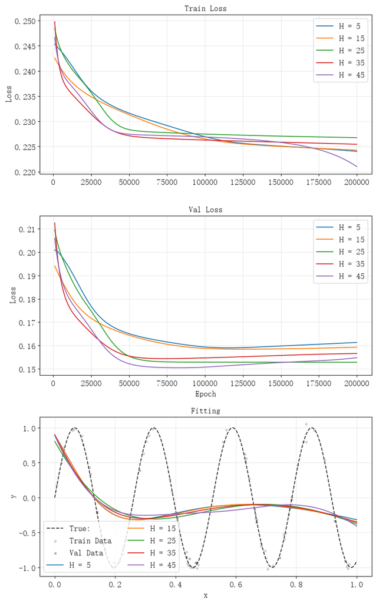

```python
fig, axes = plt.subplots(3, 1, figsize=(10, 15))
axes[0].sharex(axes[1])

start_epoch = 1000
step = max(1, (epochs - start_epoch) // 5000)
epoch_axis = np.arange(start_epoch + 1, epochs + 1, step)

axes[2].plot(x_grid, y_grid, "k--", lw=1.5, alpha=0.8, label="True:")
axes[2].scatter(x_train, y_train, s=12, alpha=0.3, color="gray", label="Train Data")
axes[2].scatter(x_val, y_val, s=12, alpha=0.35, color="black", marker="x", label="Val Data")

for i, H in enumerate(Hs):
    color = f"C{i}"
    axes[0].plot(
        epoch_axis,
        train_histories[i, start_epoch::step],
        color=color,
        label=f"H = {H}"
    )
    axes[1].plot(
        epoch_axis,
        val_histories[i, start_epoch::step],
        color=color,
        label=f"H = {H}"
    )
    y_pred = predict(x_grid, W1s[i, :, :H], W2s[i, :H + 1, :])
    axes[2].plot(x_grid, y_pred, color=color, label=f"H = {H}")

for ax, title in zip(axes[:2], ["Train Loss", "Val Loss"]):
    ax.set(title=title, ylabel="Loss")
    ax.legend()
    ax.grid(True, alpha=0.3)

axes[1].set_xlabel("Epoch")
axes[2].set(title="Fitting", xlabel="x", ylabel="y")
axes[2].legend(ncol=2)
axes[2].grid(True, alpha=0.3)
display_inline(fig)
```

可以看到，Loss 下降比较稳定，没有出现峰. 但所有网络都没有学习到高频特征.

这里我们认为是由于学习率变小，需要更长的训练 Epoch，我们增长 Epoch 观察.

```python
Hs = np.array([5, 15, 25, 35, 45])
rngs = tuple(np.random.default_rng(3407) for _ in Hs)
epochs = 2000000
lr = 0.05

train_histories, val_histories, W1s, W2s = scan_H(
    Hs, rngs, x_train, x_val, y_train, y_val, epochs, lr
)
```

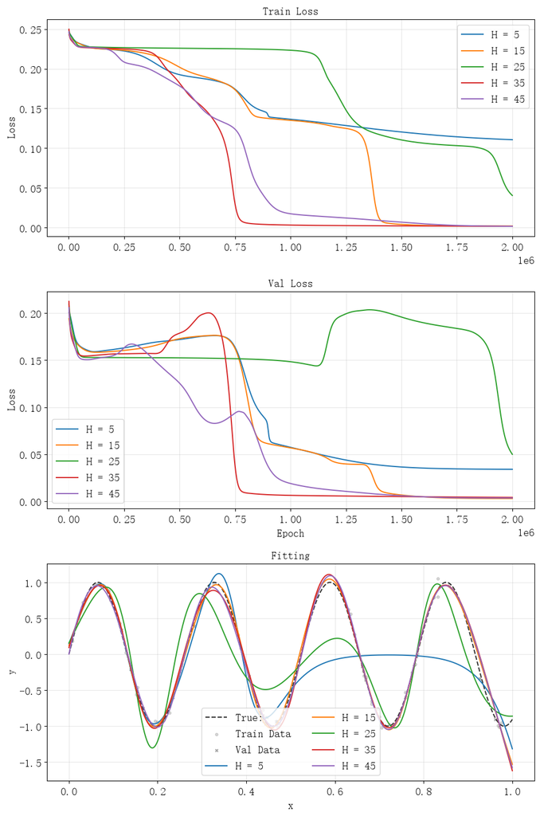

```python
fig, axes = plt.subplots(3, 1, figsize=(10, 15))
axes[0].sharex(axes[1])

start_epoch = 1000
step = max(1, (epochs - start_epoch) // 5000)
epoch_axis = np.arange(start_epoch + 1, epochs + 1, step)

axes[2].plot(x_grid, y_grid, "k--", lw=1.5, alpha=0.8, label="True:")
axes[2].scatter(x_train, y_train, s=12, alpha=0.3, color="gray", label="Train Data")
axes[2].scatter(x_val, y_val, s=12, alpha=0.35, color="black", marker="x", label="Val Data")

for i, H in enumerate(Hs):
    color = f"C{i}"
    axes[0].plot(
        epoch_axis,
        train_histories[i, start_epoch::step],
        color=color,
        label=f"H = {H}"
    )
    axes[1].plot(
        epoch_axis,
        val_histories[i, start_epoch::step],
        color=color,
        label=f"H = {H}"
    )
    y_pred = predict(x_grid, W1s[i, :, :H], W2s[i, :H + 1, :])
    axes[2].plot(x_grid, y_pred, color=color, label=f"H = {H}")

for ax, title in zip(axes[:2], ["Train Loss", "Val Loss"]):
    ax.set(title=title, ylabel="Loss")
    ax.legend()
    ax.grid(True, alpha=0.3)

axes[1].set_xlabel("Epoch")
axes[2].set(title="Fitting", xlabel="x", ylabel="y")
axes[2].legend(ncol=2)
axes[2].grid(True, alpha=0.3)
display_inline(fig)
```

可以看见，现在较宽的网络已经基本能拟合我们的曲线了.

从这一次加上前几次的 Loss 中，我们也可以看到：

- 所有网络都有“平台区”，在其中 Loss 基本不进一步下降，网络只拟合少数几个峰（开始时则可能一个峰都不拟合）但某一时刻突然优化使得 Loss 突然进一步下降，进入另一个“平台期”
- 不同宽度的网络逃离“平台区”的速度不同，大体而言，$H$ 较大逃离较快，但 $H=15$ vs $H=25$ 和 $H=35$ vs $H=45$ 不满足，可能是因为不同网络初始化的情况不同，有些网络虽然较浅，但随机初始化较好，更容易训练. 后续可以通过不同种子初始化 + 误差带的方式进一步验证（受限于时间和计算量，这里暂时不再进一步随机采样统计）
- 在平台区的时候，Val Loss 缓慢上升，呈现一定的过拟合特性，但越过平台期后，Val Loss 随 Train Loss 突然下降.

这里为何网络更宽一般更容易收敛更快，这里给出一个猜测：对于 1-H-1 的网络，不同隐藏神经元基本上是独立的. 当少数几个神经元初始化较好，较快脱离平台期时，整体网络的 Loss 突然下降. 对于更宽的网络，在随机初始化下，初始化较好的网络出现概率更大，因此整体 Loss 脱离平台区下降更快.

## 最优模型评估

最后我们分析对比不同的 $H$ 在 $2\times 10 ^6$ 的 Epoch 下的 Test Loss.

|  | H | Train Loss | Val Loss | Test Loss | Test RMSE | Test R2 |
| --- | --- | --- | --- | --- | --- | --- |
| 0 | 5 | 0.11069 | 0.03395 | 0.16366 | 0.5721 | -0.0374 |
| 1 | 15 | 0.00191 | 0.00288 | 0.00315 | 0.0794 | 0.9800 |
| 2 | 25 | 0.04053 | 0.04988 | 0.08421 | 0.4104 | 0.4662 |
| 3 | 35 | 0.00182 | 0.00408 | 0.00321 | 0.0801 | 0.9797 |
| 4 | 45 | 0.00169 | 0.00344 | 0.00221 | 0.0665 | 0.9860 |

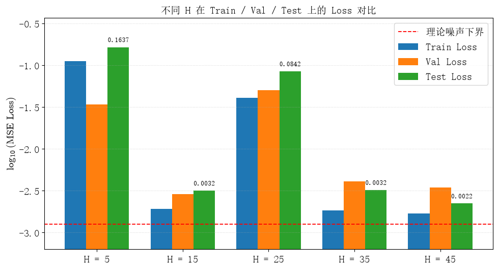

```python
def half_mse(y_pred, y_true):
    return 0.5 * np.mean((y_pred - y_true) ** 2)

def rmse(y_pred, y_true):
    return np.sqrt(np.mean((y_pred - y_true) ** 2))

def r2_score(y_pred, y_true):
    return 1.0 - np.sum((y_true - y_pred) ** 2) / np.sum((y_true - np.mean(y_true)) ** 2)

records = []
for i, H in enumerate(Hs):
    W1 = W1s[i, :, :H]
    W2 = W2s[i, :H + 1, :]
    p_tr = predict(x_train, W1, W2)
    p_va = predict(x_val, W1, W2)
    p_te = predict(x_test, W1, W2)
    records.append({
        "H": int(H),
        "Train Loss": half_mse(p_tr, y_train),
        "Val Loss": half_mse(p_va, y_val),
        "Test Loss": half_mse(p_te, y_test),
        "Test RMSE": rmse(p_te, y_test),
        "Test R2": r2_score(p_te, y_test),
    })

eval_df = pd.DataFrame(records)
display(eval_df.style.format({
    "Train Loss": "{:.5f}", "Val Loss": "{:.5f}",
    "Test Loss": "{:.5f}", "Test RMSE": "{:.4f}", "Test R2": "{:.4f}"
}))

fig, ax = plt.subplots(figsize=(10, 5.5))

x_pos = np.arange(len(Hs))
w = 0.25

log_tr = np.log10(eval_df["Train Loss"])
log_va = np.log10(eval_df["Val Loss"])
log_te = np.log10(eval_df["Test Loss"])
log_floor = np.log10(0.5 * noise_std ** 2)

# 设定基线，避免负对数值使柱子从 0 向下倒挂
y_min = np.floor(min(log_tr.min(), log_va.min(), log_te.min(), log_floor) * 2) / 2 - 0.2
y_max = max(log_tr.max(), log_va.max(), log_te.max()) + 0.35

ax.bar(x_pos - w, log_tr - y_min, w, bottom=y_min, label="Train Loss")
ax.bar(x_pos,     log_va - y_min, w, bottom=y_min, label="Val Loss")
b_te = ax.bar(x_pos + w, log_te - y_min, w, bottom=y_min, label="Test Loss")

ax.axhline(log_floor, color="r", ls="--", lw=1.3, label=r"理论噪声下界")

ax.set_xticks(x_pos)
ax.set_xticklabels([f"H = {h}" for h in Hs])
ax.set_ylim(y_min, y_max)
ax.set(
    ylabel=r"$\log_{10}(\mathrm{MSE\ Loss})$",
    title="不同 H 在 Train / Val / Test 上的 Loss 对比"
)
ax.grid(True, axis="y", ls=":", alpha=0.5)
ax.legend()

for bar, val in zip(b_te, eval_df["Test Loss"]):
    ax.text(
        bar.get_x() + bar.get_width() / 2, np.log10(val) + 0.05,
        f"{val:.4f}", ha="center", va="bottom", fontsize=9
    )

display_inline(fig)
```

可见，在此次训练中，$H=15$ $H=35$ $H=45$ 均达到较低的 Loss. 且 $H=45$ 的 Test Loss 最小. 其 Test Loss 为 0.00221，Test $R^2$ 为 0.9860. 同时，Loss 仍旧大于理论噪声下界，说明即使 Epoch 到 $2 \times 10^6$ 仍旧没有过拟合. 应该仍旧是训练 Epoch 不够导致的. 理论上 Epoch 足够则会进入过拟合.

## 不同阶段的拟合曲线和特征空间函数曲线

我们选取 $H=15$ 作为我们的研究网络（Loss 阶段性比较明显，而且 H 相对较小，方便可视化）.

我们重新训练此网络，但每 $2000$ Epoch 记录一次拟合曲线和特征空间中每一个神经元的函数曲线.

这里对于每一个神经元的函数曲线，我们定义为：

$$ h_i = W^{(2)}_i \cdot \sigma ( W^{(1)}_ik a_k ) $$

其中 $a_k$ 是输入，$W^{(1)}$ 是第一层权重，$W^{(2)}$ 是第二层权重. 这样整体的拟合函数即不同 $h_i$ 的直接求和.

```python
@nb.njit
def train_with_records(dense1, sigmoid, dense2, loss_train, loss_val, x_train, x_val, x_grid, epochs, lr, record_every=2000):
    train_history = np.empty(epochs)
    val_history = np.empty(epochs)

    m = len(x_train)
    n_grid = len(x_grid)
    H = dense1.W.shape[1]

    n_records = epochs // record_every + 1
    record_epochs = np.empty(n_records, dtype=np.int64)
    fit_curves = np.empty((n_records, n_grid))
    neuron_curves = np.empty((n_records, n_grid, H))
    bias2_history = np.empty(n_records)

    a1_grid = sigmoid.forward(dense1.forward(x_grid))
    pred_grid = dense2.forward(a1_grid)
    record_epochs[0] = 0
    fit_curves[0] = pred_grid[:, 0]
    neuron_curves[0] = a1_grid * dense2.W[:-1, 0]   # h_i(x) = W^(2)_i * sigma(W^(1)_ik a_k)
    bias2_history[0] = dense2.W[-1, 0]              # 第二层偏置 b^(2)

    rec_idx = 1
    for epoch in range(epochs):
        z1 = dense1.forward(x_train)
        a1 = sigmoid.forward(z1)
        pred = dense2.forward(a1)
        loss_train.forward(pred)
        grad = loss_train.backward()
        grad = dense2.backward(grad)
        grad = sigmoid.backward(grad)
        dense1.backward(grad)
        dense1.update(lr, m)
        dense2.update(lr, m)

        train_pred = dense2.forward(sigmoid.forward(dense1.forward(x_train)))
        val_pred = dense2.forward(sigmoid.forward(dense1.forward(x_val)))
        train_history[epoch] = loss_train.forward(train_pred) / m
        val_history[epoch] = loss_val.forward(val_pred) / len(x_val)

        # 每 record_every 轮记录整体拟合曲线与各神经元函数曲线
        if (epoch + 1) % record_every == 0:
            a1_grid = sigmoid.forward(dense1.forward(x_grid))
            pred_grid = dense2.forward(a1_grid)
            record_epochs[rec_idx] = epoch + 1
            fit_curves[rec_idx] = pred_grid[:, 0]
            neuron_curves[rec_idx] = a1_grid * dense2.W[:-1, 0]
            bias2_history[rec_idx] = dense2.W[-1, 0]
            rec_idx += 1

    return (
        train_history, val_history,
        record_epochs, fit_curves, neuron_curves, bias2_history,
    )
```

```python
H = 15
rng = np.random.default_rng(3407)
epochs = 2000000
lr = 0.05
record_every = 2000

dense1 = Dense(1, H, rng)
sigmoid = Sigmoid()
dense2 = Dense(H, 1, rng)
loss_train = MSELoss(y_train)
loss_val = MSELoss(y_val)

(
    train_history, val_history, record_epochs,
    fit_curves, neuron_curves, bias2_history
) = train_with_records(
    dense1, sigmoid, dense2, loss_train, loss_val,
    x_train, x_val, x_grid, epochs, lr, record_every
)
```

Loss 曲线：

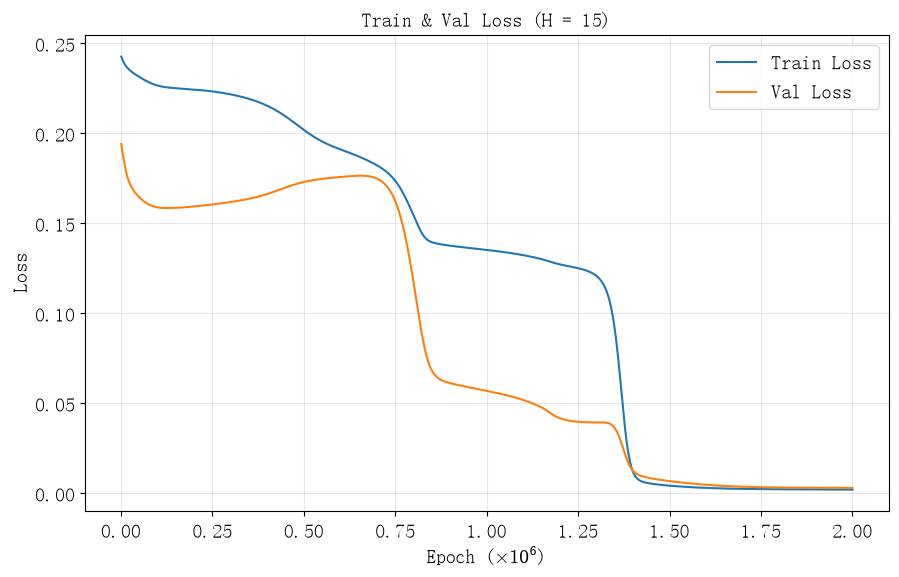

```python
start_epoch = 1000
step = max(1, (epochs - start_epoch) // 5000)
epoch_axis = np.arange(start_epoch + 1, epochs + 1, step) / 1e6

fig, ax = plt.subplots(figsize=(10, 6))

ax.plot(epoch_axis, train_history[start_epoch::step], label="Train Loss")
ax.plot(epoch_axis, val_history[start_epoch::step], label="Val Loss")

ax.set(
    title=f"Train & Val Loss (H = {H})",
    xlabel="Epoch ($\\times 10^6$)",
    ylabel="Loss",
)
ax.legend()
ax.grid(True, alpha=0.3)
display_inline(fig)
```

我们画出不同 Epoch 对应的拟合曲线.

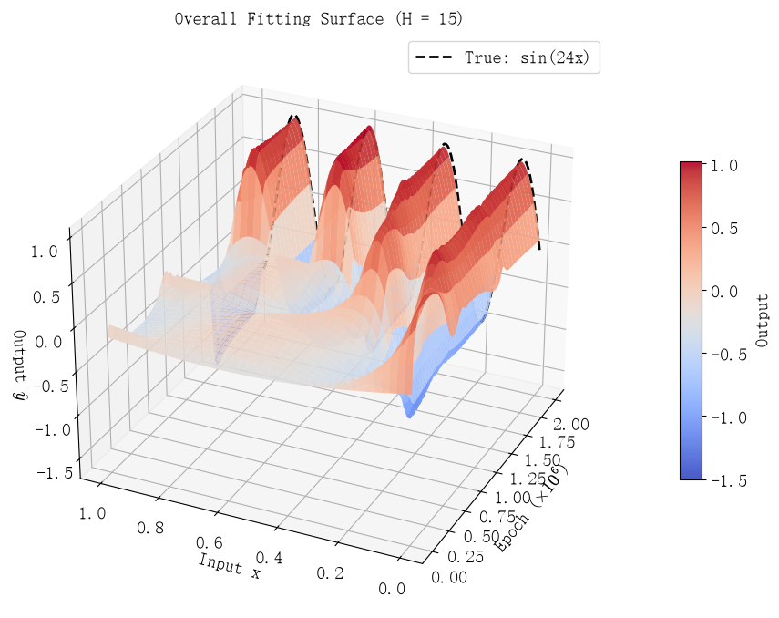

```python
# 降采样避免 2001x500 网格渲染过慢
epoch_step = max(1, len(record_epochs) // 200)
x_step = max(1, len(x_grid) // 150)

epochs_sub = record_epochs[::epoch_step] / 1e6
x_sub = x_grid[::x_step, 0]
Z_fit = fit_curves[::epoch_step, ::x_step]

X, Y = np.meshgrid(epochs_sub, x_sub, indexing="ij")

fig = plt.figure(figsize=(11, 7))
ax = fig.add_subplot(111, projection="3d")

surf = ax.plot_surface(
    X, Y, Z_fit,
    cmap="coolwarm",
    linewidth=0,
    antialiased=True,
    alpha=0.92,
)

# 在最终 Epoch 切面叠加真实函数曲线作参考
ax.plot(
    np.full_like(x_sub, epochs_sub[-1]),
    x_sub,
    y_grid[::x_step, 0],
    "k--",
    lw=2.0,
    label="True: sin(24x)",
)

ax.set(
    title=f"Overall Fitting Surface (H = {H})",
    xlabel="Epoch ($\\times 10^6$)",
    ylabel="Input x",
    zlabel="Output $\\hat{y}$",
)
ax.view_init(elev=28, azim=-155)
ax.legend(loc="upper right")
fig.colorbar(surf, ax=ax, shrink=0.55, aspect=14, pad=0.08, label="Output")
display_inline(fig)
```

结合三维演化曲面图与学习曲线，可以总结模型输出函数 $\hat{y}(x)$ 随训练阶段演化的规律如下：

- 先低频、后高频：训练初期曲面沿输入轴 $x$ 十分平缓，模型首先学习目标函数 $\sin(24x)$ 的均值与低频缓慢趋势，随后才逐步拟合出周期更短的高频振荡.
- 曲面形态演化与 Loss 阶梯严格对应：在 Loss 处于平台期时，三维曲面沿 Epoch 方向几乎保持“平直延伸”，拟合曲线形态停滞；而每当 Loss 发生阶梯式陡降（如 $0.8\times 10^6$ 与 $1.35\times 10^6$ Epoch 附近），曲面便会在对应的 $x$ 区间迅速“折叠”并长出新的波峰与波谷
- 逐步补全：模型并非同时在整个 $[0,1]$ 区间均匀学会全部振荡，而是分阶段逐段捕获部分周期

我们进一步画出不同神经元函数曲线变化过程.

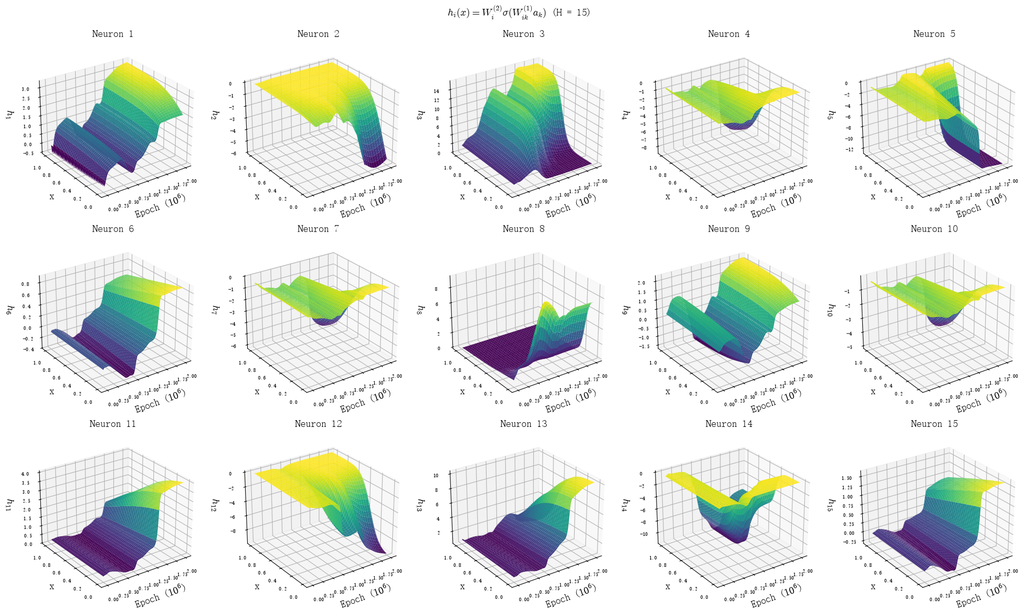

```python
# 多子图适当提高降采样步长以加快渲染
epoch_step_n = max(1, len(record_epochs) // 100)
x_step_n = max(1, len(x_grid) // 80)

epochs_sub_n = record_epochs[::epoch_step_n] / 1e6
x_sub_n = x_grid[::x_step_n, 0]
Xn, Yn = np.meshgrid(epochs_sub_n, x_sub_n, indexing="ij")

fig, axes = plt.subplots(3, 5, figsize=(20, 12), subplot_kw={"projection": "3d"},)
for i, ax in enumerate(axes.flat):
    Zi = neuron_curves[::epoch_step_n, ::x_step_n, i]
    ax.plot_surface(
        Xn, Yn, Zi,
        cmap="viridis",
        linewidth=0,
        antialiased=True,
    )
    ax.set(
        title=f"Neuron {i + 1}",
        xlabel="Epoch ($10^6$)",
        ylabel="x",
        zlabel=f"$h_{{{i + 1}}}$",
    )
    ax.view_init(elev=26, azim=-125)
    ax.tick_params(labelsize=7)
fig.suptitle(f"$h_i(x) = W_i^{{(2)}} \\sigma(W_{{ik}}^{{(1)}} a_k)$ (H = {H})", fontsize=14)
display_inline(fig)
```

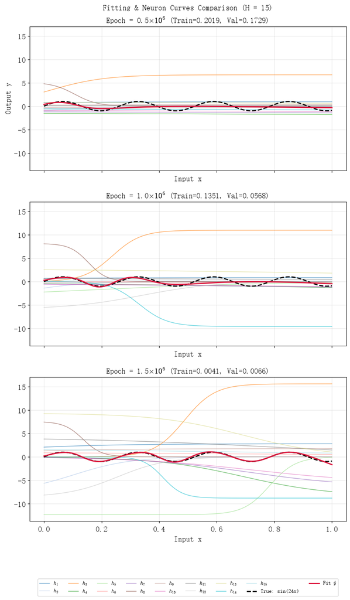

```python
target_epochs = [500_000, 1_000_000, 1_500_000]
x_1d = x_grid[:, 0]
y_true = y_grid[:, 0]
colors = plt.cm.tab20(np.linspace(0, 1, H))

fig, axes = plt.subplots(3, 1, figsize=(10, 15), sharex=True, sharey=True)

for ax, ep in zip(axes, target_epochs):
    idx = np.argmin(np.abs(record_epochs - ep))
    actual_ep = int(record_epochs[idx])
    for i in range(H):
        ax.plot(
            x_1d,
            neuron_curves[idx, :, i],
            color=colors[i],
            lw=1.1,
            alpha=0.65,
            label=f"$h_{{{i + 1}}}$",
        )
    ax.plot(x_1d, y_true, "k--", lw=2.0, zorder=10, label="True: sin(24x)")
    ax.plot(x_1d, fit_curves[idx], color="crimson", lw=2.2, zorder=11, label="Fit $\\hat{y}$")

    loss_idx = max(0, actual_ep - 1)
    ax.set_title(
        f"Epoch = {actual_ep / 1e6:.1f}$\\times 10^6$ (Train={train_history[loss_idx]:.4f}, Val={val_history[loss_idx]:.4f})"
    )
    ax.set_xlabel("Input x")
    ax.grid(True, alpha=0.3)

axes[0].set_ylabel("Output y")

handles, labels = axes[0].get_legend_handles_labels()
fig.legend(
    handles, labels,
    loc="lower center",
    ncol=9,
    bbox_to_anchor=(0.5, -0.02),
    frameon=True,
    fontsize=9,
)

fig.suptitle(f"Fitting & Neuron Curves Comparison (H = {H})", fontsize=14)
display_inline(fig)
```

在三阶段剖面对比图中，整体预测曲线由各隐含层神经元的加权特征函数 $h_i(x) = W^{(2)}_i \cdot \sigma\!\left(W^{(1)}_{ik} a_k\right)$ 直接叠加（加输出偏置）而成.

从图中可以看到，开始我们的神经元有且只有两个是随 $x$ 有明显变化的，这两个的组合成功拟合了第一个峰

之后，又有新的神经元开始随 $x$ 有明显变化，从而进一步拟合第二个峰

以此，模型依次拟合峰，直到所有峰都被拟合.

## 为何从 x=0 开始拟合

另外，我们可以发现，每次拟合都是先从 $x=0$ 开始向 $x=1$ 拟合. 这个现象比较容易理解. 网络第一层偏置初始化为 $b^{(1)}_i = 0$，导致所有隐含层神经元的 Sigmoid 拐点 $x_i^* = -b^{(1)}_i/w^{(1)}_i$ 在初始时刻全部位于 $x=0$，靠近 $x=0$ 处处于 Sigmoid 的高敏感区，而靠近 $x=1$ 处更容易进入饱和区、梯度相对衰减，因此 $x=0$ 附近的波形最先被拟合. 一旦 $x=0$ 附近的拟合足够好，剩余神经元 Offset 开始增大，敏感区开始向右移动，从而拟合下个一峰.

我们可以绘制“敏感区”随 Epoch 的变化

```python
@nb.njit
def train_record_inflections(
    x_train, y_train, x_val, y_val,
    dense1, sigmoid, dense2,
    epochs, lr, record_every=1000
):
    m = len(x_train)
    m_val = len(x_val)
    H = dense1.W.shape[1]
    loss_train = MSELoss(y_train)
    loss_val = MSELoss(y_val)

    n_rec = epochs // record_every + 1
    record_epochs = np.zeros(n_rec, dtype=np.int64)
    train_loss_rec = np.zeros(n_rec, dtype=np.float64)
    val_loss_rec = np.zeros(n_rec, dtype=np.float64)
    inflections = np.empty((n_rec, H), dtype=np.float64)
    w2_rec = np.empty((n_rec, H), dtype=np.float64)

    train_pred = dense2.forward(sigmoid.forward(dense1.forward(x_train)))
    val_pred = dense2.forward(sigmoid.forward(dense1.forward(x_val)))
    record_epochs[0] = 0
    train_loss_rec[0] = loss_train.forward(train_pred) / m
    val_loss_rec[0] = loss_val.forward(val_pred) / m_val
    for h in range(H):
        w = dense1.W[0, h]
        b = dense1.W[1, h]
        inflections[0, h] = -b / w if abs(w) > 1e-12 else np.nan
        w2_rec[0, h] = dense2.W[h, 0]

    rec_idx = 1
    for epoch in range(epochs):
        z1 = dense1.forward(x_train)
        a1 = sigmoid.forward(z1)
        pred = dense2.forward(a1)
        loss_train.forward(pred)

        grad = loss_train.backward(1.0)
        grad = dense2.backward(grad)
        grad = sigmoid.backward(grad)
        dense1.backward(grad)

        dense1.update(lr, m)
        dense2.update(lr, m)

        if (epoch + 1) % record_every == 0:
            train_pred = dense2.forward(sigmoid.forward(dense1.forward(x_train)))
            val_pred = dense2.forward(sigmoid.forward(dense1.forward(x_val)))
            record_epochs[rec_idx] = epoch + 1
            train_loss_rec[rec_idx] = loss_train.forward(train_pred) / m
            val_loss_rec[rec_idx] = loss_val.forward(val_pred) / m_val
            for h in range(H):
                w = dense1.W[0, h]
                b = dense1.W[1, h]
                inflections[rec_idx, h] = -b / w if abs(w) > 1e-12 else np.nan
                w2_rec[rec_idx, h] = dense2.W[h, 0]
            rec_idx += 1

    return record_epochs, train_loss_rec, val_loss_rec, inflections, w2_rec
```

```python
H, epochs, lr = 15, 2_000_000, 0.05
rng = np.random.default_rng(3407)
dense1, sigmoid, dense2 = Dense(1, H, rng), Sigmoid(), Dense(H, 1, rng)

rec_ep, t_loss, v_loss, inflections, w2_rec = train_record_inflections(
    x_train, y_train, x_val, y_val,
    dense1, sigmoid, dense2, epochs, lr, record_every=1000
)
```

```python
def plot_inflection_evolution(
    record_epochs, train_loss_rec, val_loss_rec, inflections,
    dense1, sigmoid, dense2, x_train, y_train, lr
):
    H = inflections.shape[1]
    ep_m = record_epochs / 1e6
    final_inf = inflections[-1]
    final_w2 = dense2.W[:-1, 0]
    order = np.argsort(final_inf)
    cmap = plt.get_cmap("tab20")
    colors = [cmap(i % 20) for i in range(H)]

    fig, axes = plt.subplots(3, 1, figsize=(10, 15))

    # 1. Loss 曲线
    axes[0].plot(ep_m, train_loss_rec, lw=2.0, label="Train Loss")
    axes[0].plot(ep_m, val_loss_rec, lw=1.8, ls="--", label="Val Loss")
    axes[0].set_title(f"1-{H}-1 Loss (lr={lr})")
    axes[0].set_ylabel("MSE Loss")
    axes[0].set_xlabel(r"Epoch ($\times 10^6$)")
    axes[0].grid(True, ls=":", alpha=0.5)
    axes[0].legend()

    # 2. 各神经元拐点随 Epoch 变化
    axes[1].axhspan(0.0, 1.0, color="#eef5fc", alpha=0.55, zorder=0)
    for k in range(1, 8):
        axes[1].axhline(k * np.pi / 24.0, color="gray", ls="--", lw=0.75, alpha=0.45)

    for rank, h in enumerate(order):
        traj = inflections[:, h].copy()
        # 屏蔽 w_i 过零点引起的无穷大跳变连线
        jump = np.abs(np.diff(traj, prepend=traj[0])) > 0.25
        traj[jump] = np.nan
        is_active = abs(final_w2[h]) > 4.0 and (0.0 <= final_inf[h] <= 1.0)
        axes[1].plot(
            ep_m, traj, color=colors[rank],
            lw=2.0 if is_active else 1.0,
            alpha=0.95 if is_active else 0.55,
            ls="-" if is_active else ":",
            label=f"N{h:02d}"
        )

    axes[1].set_title(r"各隐含层神经元拐点位置 $x_i^* = -b_i / w_i$ 随 Epoch 的演化轨迹")
    axes[1].set_ylabel(r"拐点位置 $x_i^*$")
    axes[1].set_xlabel(r"Epoch ($\times 10^6$)")
    axes[1].set_ylim(-0.18, 1.08)
    axes[1].grid(True, ls=":", alpha=0.5)
    axes[1].legend(loc="center left", bbox_to_anchor=(1.01, 0.5), fontsize=8.2)

    # 3. 最终拟合曲线与终态活跃拐点位置
    x_grid = np.linspace(0.0, 1.0, 500).reshape(-1, 1)
    y_pred = dense2.forward(sigmoid.forward(dense1.forward(x_grid)))
    axes[2].plot(x_grid, np.sin(24.0 * x_grid), "k--", lw=1.6, label=r"True: $\sin(24x)$")
    axes[2].plot(x_grid, y_pred, color="#d62728", lw=2.0, label="Model Final Fit")
    axes[2].scatter(x_train, y_train, s=14, color="gray", alpha=0.45, label="Train Data")
    for rank, h in enumerate(order):
        if 0.0 <= final_inf[h] <= 1.0 and abs(final_w2[h]) > 4.0:
            axes[2].axvline(final_inf[h], color=colors[rank], ls="-.", lw=1.25, alpha=0.8)
    axes[2].set_title(r"最终拟合曲线与主要活跃神经元拐点位置（$|W_2|>4$）")
    axes[2].set_xlabel(r"输入 $x$")
    axes[2].set_ylabel(r"输出 $y$")
    axes[2].set_xlim(0.0, 1.0)
    axes[2].grid(True, ls=":", alpha=0.5)
    axes[2].legend(ncol=3)
    display_inline(fig)
```

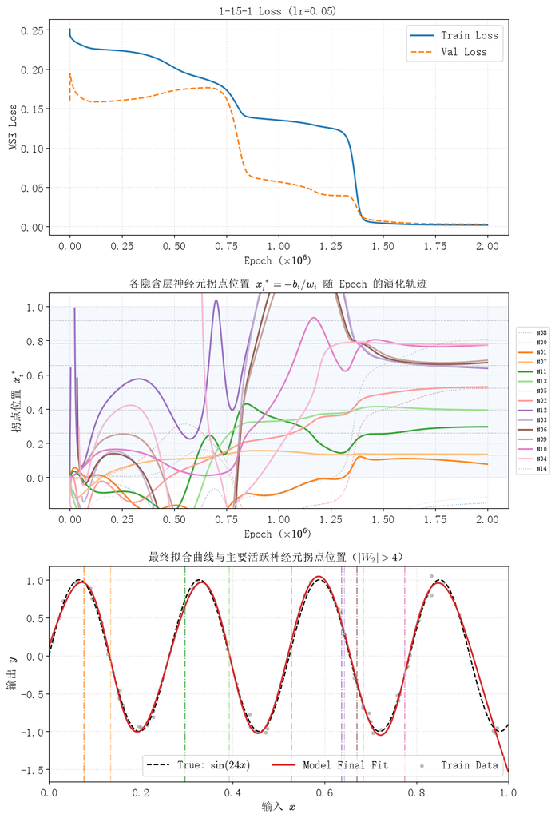

```python
plot_inflection_evolution(
    rec_ep, t_loss, v_loss, inflections,
    dense1, sigmoid, dense2, x_train, y_train, lr
)
```

## 自动微分

这里简单介绍一下自动微分

前面我们将各个层抽象成类有一个好处，就是每一个层的前项传播反向传播形式上是相同的，因此我们只需要自动记录数据经过了哪一些层即可实现自动微分. 每经过一个层，我们就在这个变量内部（变量本身也可以抽象成一个类）记录其经过了这个层，从而实现最简单的一个自动微分.

```python
class Tensor:
    def __init__(self, data, parent=None, layer=None, ctx=None):
        self.data = np.asarray(data)
        self.parent = parent
        self.layer = layer
        self.ctx = ctx
        self.grad = None

    def apply(self, layer):
        out = layer.forward(self.data)
        return Tensor(out, parent=self, layer=layer, ctx=layer.cache)

    def backward(self, grad=None):
        if grad is None:
            if self.data.size != 1:
                raise ValueError("Non-scalar output requires grad")
            grad = np.ones_like(self.data)
        node = self
        while node.layer is not None:
            node.grad = grad
            grad = node.layer.backward(grad, node.ctx)
            node = node.parent
        node.grad = grad
        return grad

    def numpy(self):
        return self.data

    def __array__(self, dtype=None, copy=None):
        a = np.asarray(self.data, dtype=dtype)
        return a.copy() if copy else a
```

```python
class Sequential:
    def __init__(self, *layers):
        self.layers = list(layers)

    def forward(self, x):
        for layer in self.layers:
            x = layer.forward(x)
        return x

    def backward(self, grad):
        for layer in reversed(self.layers):
            grad = layer.backward(grad)
        return grad

    def __call__(self, x):
        x = Tensor(x)
        for layer in self.layers:
            x = x.apply(layer)
        return x

    def update(self, lr, m):
        for layer in self.layers:
            layer.update(lr, m)
```

这里 `Tensor` 类会自动记录经过的层，`Sequential` 类会自动进行正向传播，反向传播和梯度下降，整个过程可以抽象成类似 `sklearn` 的 `pipline`. 从而使得修改网络，设计网络变得非常容易. 例如在上述过程下，重新实现 1-15-1 的网络训练为：

```python
H, lr, n_steps = 15, 0.05, 10000
m = len(x_train)

rng_ad = np.random.default_rng(3407)
train_model = Sequential(
    Dense(1, H, rng_ad),
    Sigmoid(),
    Dense(H, 1, rng_ad),
    MSELoss(y_train),
)
ad_losses = np.empty(n_steps)
for step in range(n_steps):
    loss = train_model(x_train)
    ad_losses[step] = loss.data / m
    loss.backward(1.0)
    train_model.update(lr, m)
```

和手动实现的进行对比：

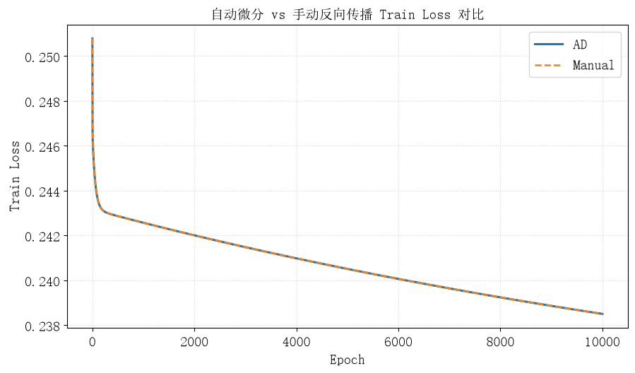

```python
rng_man = np.random.default_rng(3407)
d1_m, sig_m, d2_m = Dense(1, H, rng_man), Sigmoid(), Dense(H, 1, rng_man)
loss_m_fn = MSELoss(y_train)

man_losses = np.empty(n_steps)
for step in range(n_steps):
    pred_m = d2_m.forward(sig_m.forward(d1_m.forward(x_train)))
    man_losses[step] = loss_m_fn.forward(pred_m) / m
    grad = loss_m_fn.backward(1.0)
    grad = d2_m.backward(grad)
    grad = sig_m.backward(grad)
    d1_m.backward(grad)
    d1_m.update(lr, m)
    d2_m.update(lr, m)

epochs_axis = np.arange(1, n_steps + 1)
fig, ax = plt.subplots(figsize=(10, 5.5))
ax.plot(epochs_axis, ad_losses, lw=2.2, label="AD")
ax.plot(epochs_axis, man_losses, ls="--", lw=1.8, label="Manual")
ax.set(
    xlabel="Epoch",
    ylabel="Train Loss",
    title=f"自动微分 vs 手动反向传播 Train Loss 对比",
)
ax.grid(True, ls=":", alpha=0.5)
ax.legend()
display_inline(fig)
```

可见自动微分得到的 Loss 曲线和手动实现的相同.

当然，这里自动微分拆的比较“粗”，只是拆到层的运算. 实际 Pytorch 和 Jax 的自动微分则是拆到 Tensor 的加减乘除的基本运算上，因此其实现会更复杂，功能也更自由一些. 但其基本原理类似：每一个 Tensor 自动记录经过了什么操作，人工编写每一个最基本操作的梯度传播，之后按链式法则自动反向传播实现自动微分.

实际上，有些时候，为了加速层的运算，对于某一个层（或者某一个算子），我们希望这一个层是作为整体不可再细分的（可能是某些特殊的层，也可能是为了加速这个层的运算），此时也就需要类似这里的层一样，手动给出层（或者算子）的正向传播和反向传播的过程.

## 结论

本次实验以 $f(x)=\sin(24x)$ 加高斯噪声（$\sigma=0.05$）为数据集，使用 Einstein 求和约定推导反向传播并实现 1-H-1 多层感知机与简易自动微分，得到如下结论：

- 训练与超参影响
  - 学习率过大（如 $\eta=0.5$）时模型后期难以收敛，且 $H$ 越大越容易梯度不稳定、出现 Loss 尖峰；减小学习率（$\eta=0.05$）后训练更稳定，但需要更长 Epoch.
  - 在 $\eta=0.05$、$2\times 10^6$ Epoch 下，$H=15,35,45$ 均达到较低 Loss，其中 $H=45$ 最优，但仍高于理论噪声下界，未过拟合.
- 学习曲线与阶段演化规律（以 $H=15$ 为例）
  - 学习曲线呈“平台期—阶梯式陡降”特征：平台期内 Train Loss 停滞、Val Loss 缓慢上升，脱离平台区后两者同步陡降；总体上 $H$ 越大越容易更快脱离平台期. 猜测是由于 $H$ 较大时更容易出现初始化较好的神经元.
  - 模型输出函数 $\hat{y}(x)$ 呈“从左到右逐渐拟合峰”的规律，与 Loss 平台区严格对应，逐段拟合波形.
  - 隐含层特征函数 $h_i(x)$ 逐批被激活叠加拟合各波峰
  - 由于第一层偏置初始化为 $b_i^{(1)}=0$，初始拐点 $x_i^*=-b_i^{(1)}/w_i^{(1)}$ 集中在 $x=0$，故网络总是从 $x=0$ 向 $x=1$ 逐段拟合，终态活跃神经元拐点大体在曲线变化最剧烈的地方附近.
- 模块化与自动微分
  - 将 `Dense`、`Sigmoid`、`MSELoss` 抽象为类并结合 `Tensor`、`Sequential`，即可实一定程度的自动微分，其训练 Loss 与手动反向传播一致.

## 参考资料以及 AI 使用说明

### 参考资料

- 自动微分和层的抽象部分参考 Tariq Rashid 的《Python神经网络编程》（原书名：Make Your Own Neural Network）2018-4 出版

### AI 使用说明

- 背景补充部分个人写出大体大纲，使用 Gemini 4 Neon 生成并进行人工核验和修改.
- 代码编写使用 Deepseek V4 Flash FIM 模式进行补全和生成（尤其是绘图相关函数，基本是交给 AI 直接生成），经过人工核验和运行验证.
- 每一个层的实现和单一个神经网络的训练由个人实现，但后续参数记录的修改和批量扫参函数由 Gemini 4 Neon 生成，经过人工核验和运行验证.
- 文本和公式编写使用 Deepseek V4 Flash FIM 模式进行生成和补全，经过人工核验和修改.

## 致谢

暂无

## 附一：问题

### 为什么较大学习率下，$H$ 越大反而越容易梯度不稳定

前文在 $\eta=0.5$ 扫描 $H$ 时发现，$H$ 增大后 Train Loss 更容易出现尖峰、拟合反而更差，当时猜测是因为 $H$ 较小时当前学习率下梯度下降更稳定. 这一现象尚未进行探究. 网络变宽后，稳定学习率上界是否会随 $H$ 收缩？这是否与权重初始化有关？

### 宽网络更快逃离“平台期”是否源于随机初始化概率

我们猜测对 1-H-1 网络，各隐藏神经元近似独立，$H$ 越大时随机初始化出现较优神经元的概率越大，从而整体更快脱离平台期；但实验中也出现了 $H=15$ 快于 $H=25$、$H=35$ 快于 $H=45$ 的反例. 受限于计算量和时间，尚未通过多随机种子统计验证这一猜测是否成立.

### 继续增大 Epoch 后，模型是否一定会进入过拟合

前文在 $2\times 10^6$ Epoch 时，各宽度网络的 Loss 仍高于理论噪声下界，因此猜测仅是训练轮数不足、继续训练理论上会进入过拟合. 但全批量梯度下降在接近噪声下界后是否真的会明显过拟合，还是会停留在泛化较好的区域，尚未通过更长 Epoch 验证.

### 成功拟合是否有 $H$ 的下界

这里 sigmoid 是一个单调增大的函数，要使得能凑出峰和谷，应该需要 $2$ 个增长速度不同的 sigmoid 叠加而成，那么可以预期，对于我们的数据，要能成功拟合，其 $H$ 应该存在一个下界，是否可以进行计算？值是多少？

### 不同激活函数现象是否类似

sigmoid 在 $|x|$ 较大时其梯度较小，从而难以学习. 那么更换不容易出现小梯度的 ReLu (或者 Leaky Relu) 是否仍旧有这个现象？

### 不同优化器的效果

这里我们发现，当学习率过大，则在脱离平台区时容易出现振荡，导致梯度下降不稳定，但学习率过小则训练过慢，在平台区浪费太多 Epoch，那么换用 Adam 等自适应优化器，可否在保证没有较大振荡的情况下，使得平台区所待的时间更小？

## 附二：学习心得

暂无